> **Tip**: Welcome to the Investigate a Dataset project! You will find tips in quoted sections like this to help organize your approach to your investigation. Once you complete this project, remove these **Tip** sections from your report before submission. First things first, you might want to double-click this Markdown cell and change the title so that it reflects your dataset and investigation.

# Project: Investigate a Dataset - TMDB Movies

- Introduction
- Data Wrangling
- Exploratory Data Analysis
- Conclusions

## Introduction

### Dataset Description

> This dataset contains information about 10,000 movies collected from `TMDb` Database including user ratings, budget for each movie and revenue.

> Below is the list of columns names in our dataset and their significance
> - `id` - This is a unique identifier for each movie
> - `popularity` - A numeric quantity specifying the movie popularity
> - `budget` - The cost in which the movie was made
> - `revenue` - The worldwide revenue generated from the movie
> - `original_title` - The title of the movie before translation or adaptaion
> - `cast` - The name of lead and supporting actors
> - `homepage` - A link to the homepage of the movie
> - `director` - The directors of each movie
> - `tagline` - The movie's tagline
> - `overview` - A brief description of the movie
> - `runtime` - The running time of the movie in minutes
> - `genres` - The genre of the movies; Action, Drama,Adventure etc..
> - `Production_companies` - The production house of the movie
> - `release_date` - The date the movie was released
> - `vote_count` - The count of votes the movie received
> - `vote_average` - Average rating the movie received
> - `release_year` - The year the movie was released

### Question(s) for Analysis

> This dataset will be analysed to answer the follwing the following questions;

> ```
>  1. What year did TMDb Movies made the highest profit?
>  2. What are the top five movies when profit is expressed as a percentage of the budget for each movie?
>  3. What is the correlation between the attributes of our TMDb movies dataset?
> ```

> Before we proceed in analysing our data, we need to import certain python libraries such as Numpy, pandas, Matplotlib and seaborn which we would need to read, clean, organise and visualize our data for proper understanding.

> Below is the code for importing these libraries

```python
# Use this cell to set up import statements for all of the packages that you
#   plan to use.
# importing libraries to use
# we are going to make use of aliases for this libraries for easy callout such as np for numpy, pd for pandas etc
import numpy as np
import pandas as pd
import matplotlib.pyplot as plt #visualisation
import seaborn as sns #visualisation
%matplotlib inline
sns.set_style('darkgrid')

# Remember to include a 'magic word' so that your visualizations are plotted
#   inline with the notebook. See this page for more:
#   http://ipython.readthedocs.io/en/stable/interactive/magics.html
```

```python
# Upgrade pandas to use dataframe.explode() function.
!pip install --upgrade pandas==0.25.0
```

[output not shown]

## Data Wrangling

### General Properties

> Let's read our dataset to have a clear view of what it looks and understand its content.

```python
# Load your data and print out a few lines. Perform operations to inspect data
#   types and look for instances of missing or possibly errant data.
# reding our data stored in csv format
df = pd.read_csv('tmdb-movies.csv')
df.head()
```

|  | id | imdb_id | popularity | budget | revenue | original_title | cast | homepage | director | tagline | ... | overview | runtime | genres | production_companies | release_date | vote_count | vote_average | release_year | budget_adj | revenue_adj |
| --- | --- | --- | --- | --- | --- | --- | --- | --- | --- | --- | --- | --- | --- | --- | --- | --- | --- | --- | --- | --- | --- |
| 0 | 135397 | tt0369610 | 32.985763 | 150000000 | 1513528810 | Jurassic World | Chris Pratt\|Bryce Dallas Howard\|Irrfan Khan\|Vi... | http://www.jurassicworld.com/ | Colin Trevorrow | The park is open. | ... | Twenty-two years after the events of Jurassic ... | 124 | Action\|Adventure\|Science Fiction\|Thriller | Universal Studios\|Amblin Entertainment\|Legenda... | 6/9/15 | 5562 | 6.5 | 2015 | 1.379999e+08 | 1.392446e+09 |
| 1 | 76341 | tt1392190 | 28.419936 | 150000000 | 378436354 | Mad Max: Fury Road | Tom Hardy\|Charlize Theron\|Hugh Keays-Byrne\|Nic... | http://www.madmaxmovie.com/ | George Miller | What a Lovely Day. | ... | An apocalyptic story set in the furthest reach... | 120 | Action\|Adventure\|Science Fiction\|Thriller | Village Roadshow Pictures\|Kennedy Miller Produ... | 5/13/15 | 6185 | 7.1 | 2015 | 1.379999e+08 | 3.481613e+08 |
| 2 | 262500 | tt2908446 | 13.112507 | 110000000 | 295238201 | Insurgent | Shailene Woodley\|Theo James\|Kate Winslet\|Ansel... | http://www.thedivergentseries.movie/#insurgent | Robert Schwentke | One Choice Can Destroy You | ... | Beatrice Prior must confront her inner demons ... | 119 | Adventure\|Science Fiction\|Thriller | Summit Entertainment\|Mandeville Films\|Red Wago... | 3/18/15 | 2480 | 6.3 | 2015 | 1.012000e+08 | 2.716190e+08 |
| 3 | 140607 | tt2488496 | 11.173104 | 200000000 | 2068178225 | Star Wars: The Force Awakens | Harrison Ford\|Mark Hamill\|Carrie Fisher\|Adam D... | http://www.starwars.com/films/star-wars-episod... | J.J. Abrams | Every generation has a story. | ... | Thirty years after defeating the Galactic Empi... | 136 | Action\|Adventure\|Science Fiction\|Fantasy | Lucasfilm\|Truenorth Productions\|Bad Robot | 12/15/15 | 5292 | 7.5 | 2015 | 1.839999e+08 | 1.902723e+09 |
| 4 | 168259 | tt2820852 | 9.335014 | 190000000 | 1506249360 | Furious 7 | Vin Diesel\|Paul Walker\|Jason Statham\|Michelle ... | http://www.furious7.com/ | James Wan | Vengeance Hits Home | ... | Deckard Shaw seeks revenge against Dominic Tor... | 137 | Action\|Crime\|Thriller | Universal Pictures\|Original Film\|Media Rights ... | 4/1/15 | 2947 | 7.3 | 2015 | 1.747999e+08 | 1.385749e+09 |

5 rows × 21 columns

Above is the first five rows of our data.

We are going to view the shape of our data using the shape function to know the number of columns and rows contained in our dataset.

```python
# below is the code to view the shape of our dataset
df.shape
```

```
(10866, 21)
```

```python
# for clear understanding of the values, am using print to indicate the row value and the column value
print('The number of rows are:', df.shape[0],'.', 'The number of columns are:', df.shape[1])
```

```
The number of rows are: 10866 . The number of columns are: 21
```

To further understand our data, we are going to use the info funtion to get more information about the structure of our dataset.

```python
df.info()
```

```
<class 'pandas.core.frame.DataFrame'>
RangeIndex: 10866 entries, 0 to 10865
Data columns (total 21 columns):
id                      10866 non-null int64
imdb_id                 10856 non-null object
popularity              10866 non-null float64
budget                  10866 non-null int64
revenue                 10866 non-null int64
original_title          10866 non-null object
cast                    10790 non-null object
homepage                2936 non-null object
director                10822 non-null object
tagline                 8042 non-null object
keywords                9373 non-null object
overview                10862 non-null object
runtime                 10866 non-null int64
genres                  10843 non-null object
production_companies    9836 non-null object
release_date            10866 non-null object
vote_count              10866 non-null int64
vote_average            10866 non-null float64
release_year            10866 non-null int64
budget_adj              10866 non-null float64
revenue_adj             10866 non-null float64
dtypes: float64(4), int64(6), object(11)
memory usage: 1.7+ MB
```

### Data Cleaning

> We need to clean our data to ultimately increase the overall productivity of our data and allow the highest quality information in our decision making.

> Things we would do get our data ready are:

> ```
> 1. Remove null values / missing values.
> 2. Remove irrelevant duplicates
> ```

First we need to check for null values in our dataset

```python
#checking for number of null values in our dataset
df.isnull().sum()
```

```
id                         0
imdb_id                   10
popularity                 0
budget                     0
revenue                    0
original_title             0
cast                      76
homepage                7930
director                  44
tagline                 2824
keywords                1493
overview                   4
runtime                    0
genres                    23
production_companies    1030
release_date               0
vote_count                 0
vote_average               0
release_year               0
budget_adj                 0
revenue_adj                0
dtype: int64
```

We can see that there are several columns with null values. I will drop all this null values in the next step below

```python
# Droping all NaN and Null values in our dataset and checking if there are NaN values after dropping
df.dropna(inplace=True)

df.isnull().sum()
```

```
id                      0
imdb_id                 0
popularity              0
budget                  0
revenue                 0
original_title          0
cast                    0
homepage                0
director                0
tagline                 0
keywords                0
overview                0
runtime                 0
genres                  0
production_companies    0
release_date            0
vote_count              0
vote_average            0
release_year            0
budget_adj              0
revenue_adj             0
dtype: int64
```

Secondly, we would proceed to check for duplicated rows in the data

```python
df.duplicated().sum()
```

```
0
```

There are no duplicates in the dataset.

```python
#Rechecking the shape of the data
df.shape
```

```
(1992, 21)
```

Our rows has dropped to 1992 because of the null values we removed

Thirdly, based on the research questions questions not all columns will be needed for this analysis. I will be dropping all columns we don't need for this analysis in the next step.

```python
df.drop(columns={'imdb_id','cast','tagline','keywords','homepage','budget_adj','revenue_adj'}, axis=1, inplace=True)
```

Let's see if the columns were actually dropped

```python
df.head()
```

|  | id | popularity | budget | revenue | original_title | director | overview | runtime | genres | production_companies | release_date | vote_count | vote_average | release_year |
| --- | --- | --- | --- | --- | --- | --- | --- | --- | --- | --- | --- | --- | --- | --- |
| 0 | 135397 | 32.985763 | 150000000 | 1513528810 | Jurassic World | Colin Trevorrow | Twenty-two years after the events of Jurassic ... | 124 | Action\|Adventure\|Science Fiction\|Thriller | Universal Studios\|Amblin Entertainment\|Legenda... | 6/9/15 | 5562 | 6.5 | 2015 |
| 1 | 76341 | 28.419936 | 150000000 | 378436354 | Mad Max: Fury Road | George Miller | An apocalyptic story set in the furthest reach... | 120 | Action\|Adventure\|Science Fiction\|Thriller | Village Roadshow Pictures\|Kennedy Miller Produ... | 5/13/15 | 6185 | 7.1 | 2015 |
| 2 | 262500 | 13.112507 | 110000000 | 295238201 | Insurgent | Robert Schwentke | Beatrice Prior must confront her inner demons ... | 119 | Adventure\|Science Fiction\|Thriller | Summit Entertainment\|Mandeville Films\|Red Wago... | 3/18/15 | 2480 | 6.3 | 2015 |
| 3 | 140607 | 11.173104 | 200000000 | 2068178225 | Star Wars: The Force Awakens | J.J. Abrams | Thirty years after defeating the Galactic Empi... | 136 | Action\|Adventure\|Science Fiction\|Fantasy | Lucasfilm\|Truenorth Productions\|Bad Robot | 12/15/15 | 5292 | 7.5 | 2015 |
| 4 | 168259 | 9.335014 | 190000000 | 1506249360 | Furious 7 | James Wan | Deckard Shaw seeks revenge against Dominic Tor... | 137 | Action\|Crime\|Thriller | Universal Pictures\|Original Film\|Media Rights ... | 4/1/15 | 2947 | 7.3 | 2015 |

```python
#Lets view our data information to check if there are still errors

df.info()
```

```
<class 'pandas.core.frame.DataFrame'>
Int64Index: 1992 entries, 0 to 10819
Data columns (total 14 columns):
id                      1992 non-null int64
popularity              1992 non-null float64
budget                  1992 non-null int64
revenue                 1992 non-null int64
original_title          1992 non-null object
director                1992 non-null object
overview                1992 non-null object
runtime                 1992 non-null int64
genres                  1992 non-null object
production_companies    1992 non-null object
release_date            1992 non-null object
vote_count              1992 non-null int64
vote_average            1992 non-null float64
release_year            1992 non-null int64
dtypes: float64(2), int64(6), object(6)
memory usage: 233.4+ KB
```

There is need to convert release_date datatype to datetime

```python
df.release_date = pd.to_datetime(df.release_date)
```

```python
#check if release_date has been converted to datetime datatype
df.info()
```

```
<class 'pandas.core.frame.DataFrame'>
Int64Index: 1992 entries, 0 to 10819
Data columns (total 14 columns):
id                      1992 non-null int64
popularity              1992 non-null float64
budget                  1992 non-null int64
revenue                 1992 non-null int64
original_title          1992 non-null object
director                1992 non-null object
overview                1992 non-null object
runtime                 1992 non-null int64
genres                  1992 non-null object
production_companies    1992 non-null object
release_date            1992 non-null datetime64[ns]
vote_count              1992 non-null int64
vote_average            1992 non-null float64
release_year            1992 non-null int64
dtypes: datetime64[ns](1), float64(2), int64(6), object(5)
memory usage: 233.4+ KB
```

Let's review the statistics of our dataset to check if there are any abnormality

```python
df.describe()
```

|  | id | popularity | budget | revenue | runtime | vote_count | vote_average | release_year |
| --- | --- | --- | --- | --- | --- | --- | --- | --- |
| count | 1992.000000 | 1992.000000 | 1.992000e+03 | 1.992000e+03 | 1992.000000 | 1992.000000 | 1992.000000 | 1992.000000 |
| mean | 71652.152108 | 1.316763 | 3.454924e+07 | 1.152153e+08 | 106.040161 | 643.616968 | 6.178614 | 2007.796687 |
| std | 92355.883915 | 1.873563 | 5.061878e+07 | 2.202887e+08 | 29.234592 | 1092.355998 | 0.881955 | 7.549224 |
| min | 11.000000 | 0.000620 | 0.000000e+00 | 0.000000e+00 | 0.000000 | 10.000000 | 2.100000 | 1961.000000 |
| 25% | 9699.000000 | 0.384079 | 0.000000e+00 | 0.000000e+00 | 92.000000 | 51.000000 | 5.600000 | 2006.000000 |
| 50% | 35112.500000 | 0.774223 | 1.500000e+07 | 2.578782e+07 | 102.000000 | 210.000000 | 6.200000 | 2010.000000 |
| 75% | 83573.000000 | 1.538639 | 4.800000e+07 | 1.278787e+08 | 116.000000 | 688.250000 | 6.800000 | 2012.000000 |
| max | 414419.000000 | 32.985763 | 4.250000e+08 | 2.781506e+09 | 705.000000 | 9767.000000 | 8.300000 | 2015.000000 |

From our statistics above we can see that minimum and 25% of budget and revenue are 0, runtime has the minimum of 0 aswell which in real time context is not logical. We will proceed to fix this error in the next step

```python
#cleaning and correcting the invalid data
# we assigned the 0 values to min_ero varible
min_ero = df.query('budget == 0 or revenue == 0 or runtime ==0')
min_ero
# below id the rows with the zero (0) values which we need to drop
```

|  | id | popularity | budget | revenue | original_title | director | overview | runtime | genres | production_companies | release_date | vote_count | vote_average | release_year |
| --- | --- | --- | --- | --- | --- | --- | --- | --- | --- | --- | --- | --- | --- | --- |
| 30 | 280996 | 3.927333 | 0 | 29355203 | Mr. Holmes | Bill Condon | The story is set in 1947, following a long-ret... | 103 | Mystery\|Drama | BBC Films\|See-Saw Films\|FilmNation Entertainme... | 2015-06-19 | 425 | 6.4 | 2015 |
| 67 | 334074 | 2.331636 | 20000000 | 0 | Survivor | James McTeigue | A Foreign Service Officer in London tries to p... | 96 | Crime\|Thriller\|Action | Nu Image Films\|Winkler Films\|Millennium Films\|... | 2015-05-21 | 280 | 5.4 | 2015 |
| 75 | 308369 | 2.141506 | 0 | 0 | Me and Earl and the Dying Girl | Alfonso Gomez-Rejon | Greg is coasting through senior year of high s... | 105 | Comedy\|Drama | Indian Paintbrush | 2015-06-12 | 569 | 7.7 | 2015 |
| 88 | 301875 | 1.959765 | 0 | 2000000 | Equals | Drake Doremus | A futuristic love story set in a world where e... | 101 | Drama\|Romance\|Science Fiction | Scott Free Productions\|Infinite Frameworks Stu... | 2015-09-04 | 135 | 5.6 | 2015 |
| 95 | 258509 | 1.841779 | 0 | 233755553 | Alvin and the Chipmunks: The Road Chip | Walt Becker | Through a series of misunderstandings, Alvin, ... | 92 | Adventure\|Animation\|Comedy\|Family | Regency Enterprises\|Fox 2000 Pictures\|Sunswept... | 2015-12-17 | 278 | 5.7 | 2015 |
| 132 | 263109 | 1.253580 | 0 | 59700000 | Shaun the Sheep Movie | Mark Burton\|Richard Starzack | When Shaun decides to take the day off and hav... | 85 | Family\|Animation\|Comedy\|Adventure | Aardman Animations\|Studio Canal\|Anton Capital ... | 2015-02-05 | 340 | 6.9 | 2015 |
| 139 | 193687 | 1.161812 | 0 | 118483 | Z for Zachariah | Craig Zobel | In the wake of a nuclear war, a young woman su... | 97 | Drama\|Science Fiction\|Thriller | Palomar Pictures\|Lucky Hat Entertainment\|Silve... | 2015-08-13 | 181 | 5.5 | 2015 |
| 143 | 378373 | 1.128081 | 0 | 0 | Brothers of the Wind | Gerado Olivares\|Otmar Penker | The way of the eagle is to raise two chicks. T... | 98 | Adventure\|Drama\|Family | Terra Mater Factual Studios | 2015-12-24 | 11 | 7.5 | 2015 |
| 148 | 353326 | 1.046518 | 0 | 11472454 | The Man Who Knew Infinity | Matt Brown | Growing up poor in Madras, India, Srinivasa Ra... | 108 | Drama | Animus Films\|Edward R. Pressman Film\|Kreo Film... | 2015-09-17 | 104 | 7.1 | 2015 |
| 159 | 251516 | 0.953046 | 630019 | 0 | Kung Fury | David Sandberg | During an unfortunate series of events, a frie... | 31 | Action\|Comedy\|Science Fiction\|Fantasy | Laser Unicorns | 2015-05-28 | 487 | 7.7 | 2015 |
| 172 | 225728 | 0.874641 | 0 | 13192457 | Macbeth | Justin Kurzel | Feature film adaptation of Shakespeare's Scott... | 113 | History\|Drama\|War | Studio Canal\|See-Saw Films\|Creative Scotland\|F... | 2015-08-16 | 269 | 6.4 | 2015 |
| 173 | 326425 | 0.872149 | 0 | 16775 | Extraction | Steven C. Miller | A former CIA operative is kidnapped by a group... | 83 | Action\|Thriller | Emmett/Furla Films\|Oasis Films\|Aperture Entert... | 2015-12-18 | 57 | 4.2 | 2015 |
| 174 | 342474 | 0.861179 | 0 | 0 | Jenny's Wedding | Mary Agnes Donoghue | Jenny Farrell is getting married. But how will... | 94 | Comedy\|Drama | MM Productions\|Merced Media Partners\|PalmStar ... | 2015-07-31 | 92 | 5.2 | 2015 |
| 181 | 322456 | 0.821443 | 0 | 0 | LEGO DC Comics Super Heroes: Justice League vs... | Brandon Vietti | Superman’s clone, Bizarro, has become an emb... | 48 | Action\|Adventure\|Animation\|Family | Warner Bros. Animation | 2015-02-10 | 14 | 6.4 | 2015 |
| 187 | 334538 | 0.792471 | 0 | 0 | Into the Forest | Patricia Rozema | In the not too distant future, two young women... | 101 | Drama\|Science Fiction | Rhombus Media\|Bron Studios | 2015-06-03 | 57 | 5.1 | 2015 |
| 195 | 331781 | 0.738404 | 0 | 8413144 | Amy | Asif Kapadia | A documentary on the life of Amy Winehouse, th... | 128 | Documentary\|Music | On The Corner Films\|Universal Music | 2015-07-03 | 345 | 7.5 | 2015 |
| 197 | 312831 | 0.719407 | 0 | 0 | The Hallow | Corin Hardy | A family who moved into a remote mill house in... | 97 | Fantasy\|Horror | Prescience\|Bord Scannan na hEireann / Irish Fi... | 2015-11-06 | 122 | 4.9 | 2015 |
| 201 | 332340 | 0.701370 | 0 | 0 | Man Up | Ben Palmer | A 34 year old single woman, Nancy, hung-over a... | 88 | Romance\|Comedy | Big Talk Productions\|StudioCanal | 2015-05-29 | 264 | 6.5 | 2015 |
| 212 | 86835 | 0.654335 | 0 | 0 | Knight of Cups | Terrence Malick | Once there was a young prince whose father, th... | 118 | Romance\|Drama | Waypoint Entertainment\|Dogwood Films | 2015-09-10 | 101 | 5.7 | 2015 |
| 214 | 309242 | 0.649628 | 0 | 0 | Mississippi Grind | Ryan Fleck\|Anna Boden | Gerry is a talented but down-on-his-luck gambl... | 108 | Drama | Electric City Entertainment\|Sycamore Pictures\|... | 2015-07-04 | 74 | 5.7 | 2015 |
| 215 | 332502 | 0.644786 | 0 | 0 | 400 Days | Matt Osterman | 4 would be astronauts spend 400 days in a land... | 91 | Mystery\|Science Fiction\|Thriller | New Artists Alliance | 2015-10-29 | 98 | 4.2 | 2015 |
| 237 | 278236 | 0.547827 | 0 | 0 | X+Y | Morgan Matthews | A socially awkward teenage math prodigy finds ... | 111 | Drama | Original Pictures\|Head Gear Films\|Minnow Films | 2015-03-13 | 133 | 6.0 | 2015 |
| 239 | 326215 | 0.542568 | 6000000 | 0 | Ooops! Noah is Gone... | Toby Genkel\|Sean McCormack | It's the end of the world. A flood is coming. ... | 85 | Animation\|Adventure\|Comedy | Skyline Entertainment\|Moetion Films\|Ulysses Fi... | 2015-04-09 | 50 | 5.7 | 2015 |
| 241 | 318256 | 0.532239 | 0 | 0 | Hot Girls Wanted | Jill Bauer\|Ronna Gradus | A first-ever look at the realities of the prof... | 84 | Documentary | Two to Tangle Productions | 2015-05-29 | 158 | 5.9 | 2015 |
| 245 | 309299 | 0.526642 | 0 | 0 | Experimenter | Michael Almereyda | Yale University, 1961. Stanley Milgram designs... | 97 | History\|Drama | FJ Productions\|BB Film Productions | 2015-10-16 | 94 | 6.9 | 2015 |
| 255 | 336313 | 0.497265 | 0 | 157768 | Hell & Back | Tom Gianas\|Ross Shuman | Two best friends set out to rescue their pal a... | 86 | Fantasy\|Comedy\|Animation | Freestyle Releasing\|ShadowMachine Films | 2015-10-02 | 47 | 4.3 | 2015 |
| 261 | 289716 | 0.474788 | 0 | 0 | The World Made Straight | David Burris | In a rural Appalachian community haunted by th... | 119 | Drama | Myriad Pictures\|Dreambridge Films\|Bifrost Pict... | 2015-01-09 | 13 | 5.8 | 2015 |
| 269 | 302429 | 0.465707 | 0 | 13603453 | Strange Magic | Gary Rydstrom | A love potion works its devious charms on fair... | 99 | Music\|Animation\|Family\|Fantasy | Lucasfilm\|Touchstone Pictures | 2015-01-23 | 68 | 6.1 | 2015 |
| 272 | 323373 | 0.454151 | 0 | 0 | Deathgasm | Jason Lei Howden | Two teenage boys unwittingly summon an ancient... | 86 | Comedy\|Horror | The New Zealand Film Commission\|Timpson Films\|... | 2015-08-28 | 83 | 6.5 | 2015 |
| 285 | 318922 | 0.438409 | 0 | 0 | Kill Your Friends | Owen Harris | In the late 1990s, a drug-addled nihilist reso... | 100 | Thriller\|Comedy\|Crime | Altitude Film Entertainment\|AI-Film\|Unigram | 2015-11-06 | 54 | 5.5 | 2015 |
| ... | ... | ... | ... | ... | ... | ... | ... | ... | ... | ... | ... | ... | ... | ... |
| 8465 | 11238 | 1.841080 | 0 | 0 | Aladdin and the King of Thieves | Tad Stones | Legendary secrets are revealed as Aladdin and ... | 81 | Adventure\|Animation\|Family | Walt Disney Television Animation | 1996-05-20 | 308 | 6.2 | 1996 |
| 8651 | 3065 | 0.117864 | 0 | 0 | Mystery Science Theater 3000: The Movie | Jim Mallon | The mad and evil scientist, Dr. Clayton Forres... | 73 | Comedy\|Science Fiction | Universal Pictures\|Best Brains | 1996-04-19 | 41 | 7.0 | 1996 |
| 8733 | 19457 | 0.558581 | 0 | 0 | The Yards | James Gray | In the rail yards of Queens, contractors repai... | 115 | Drama\|Action\|Thriller\|Crime | Miramax Films\|Industry Entertainment | 2000-04-27 | 41 | 5.8 | 2000 |
| 8768 | 876 | 0.381729 | 20000000 | 0 | Frank Herbert's Dune | John Harrison | A three part mini-series based on Frank Herber... | 292 | Action\|Adventure\|Fantasy\|Science Fiction | New Amsterdam Entertainment\|Tandem Communications | 2000-12-03 | 67 | 6.5 | 2000 |
| 8803 | 41275 | 0.251747 | 0 | 0 | Python | Richard Clabaugh | Sleepy New Haven California is a small town wi... | 99 | Thriller\|Comedy\|Horror\|Science Fiction | Unified Film Organization (UFO)\|Python Product... | 2000-08-09 | 10 | 3.5 | 2000 |
| 8852 | 17908 | 0.378034 | 7000000 | 0 | My Dog Skip | Jay Russell | A shy boy is unable to make friends in Yazoo C... | 95 | Comedy\|Drama\|Family | Alcon Entertainment\|Warner Bros. | 2000-01-14 | 30 | 6.1 | 2000 |
| 8870 | 21355 | 0.084290 | 57000000 | 0 | All the Pretty Horses | Billy Bob Thornton | The year is 1949. A young Texan named John Gra... | 117 | Drama\|Romance\|Western | Columbia Pictures\|Miramax Films | 2000-12-11 | 27 | 5.5 | 2000 |
| 8876 | 21991 | 0.059043 | 0 | 0 | State and Main | David Mamet | A Hollywood Film unit invades a small Vermont ... | 102 | Comedy\|Drama | Filmtown Entertainment Group\|El Dorado Picture... | 2000-08-26 | 19 | 5.7 | 2000 |
| 9039 | 9945 | 0.626850 | 20000000 | 0 | Vampires | John Carpenter | The church enlists a team of vampire-hunters t... | 108 | Action\|Drama\|Fantasy\|Horror\|Thriller | Columbia Pictures\|Largo Entertainment\|JVC Ente... | 1998-10-30 | 109 | 5.8 | 1998 |
| 9081 | 16146 | 0.399489 | 650000 | 0 | Phantasm IV: Oblivion | Don Coscarelli | Taking off immediately where the last one ende... | 90 | Horror\|Science Fiction | Starway International Inc. | 1998-10-13 | 15 | 4.6 | 1998 |
| 9286 | 18111 | 0.190250 | 2000000 | 0 | Bride of Re-Animator | Brian Yuzna | Herbert West once again revives the dead. This... | 96 | Comedy\|Horror\|Science Fiction | Wild Street Pictures | 1989-10-01 | 24 | 5.8 | 1989 |
| 9421 | 4539 | 0.206000 | 0 | 0 | Hearts of Darkness: A Filmmaker's Apocalypse | Eleanor Coppola\|Fax Bahr\|George Hickenlooper | A chronicle of the production problems — inc... | 96 | Documentary | American Zoetrope\|Cineplex-Odeon Films | 1991-09-06 | 28 | 7.8 | 1991 |
| 9539 | 34311 | 0.254965 | 0 | 0 | Sleepaway Camp II: Unhappy Campers | Michael A. Simpson | Angela Baker, a psychotic transsexual, escapes... | 80 | Horror\|Comedy | Double Helix Films | 1988-10-31 | 20 | 6.0 | 1988 |
| 9586 | 26355 | 0.076958 | 0 | 17514553 | For Keeps | John G. Avildsen | Darcy, editor at her highschool paper, and her... | 98 | Drama\|Family\|Romance | TriStar Pictures | 1988-01-15 | 12 | 6.4 | 1988 |
| 9631 | 13247 | 0.500666 | 0 | 0 | A Muppet Family Christmas | Peter Harris\|Eric Till | In this one-hour Christmas special, Fozzie Bea... | 48 | Family\|TV Movie | Jim Henson Company, The | 1987-12-16 | 11 | 6.5 | 1987 |
| 9647 | 12476 | 0.099960 | 0 | 0 | The Hidden | Jack Sholder | An alien is on the run in America. To get his ... | 96 | Action\|Horror\|Science Fiction\|Thriller | New Line Cinema\|Heron Communications\|Third Elm... | 1987-10-30 | 26 | 6.4 | 1987 |
| 9692 | 22500 | 0.186551 | 0 | 0 | Gandahar | René Laloux | René Laloux, director of Fantastic Planet [La... | 83 | Animation\|Science Fiction\|Fantasy\|Adventure | Films A2 | 1987-12-11 | 10 | 7.2 | 1987 |
| 9708 | 59558 | 0.005529 | 0 | 0 | Miami Connection | Y.K. Kim\|Woo-sang Park | In a world where ninjas dream of being rock st... | 86 | Action\|Crime | Drafthouse Films | 1987-08-18 | 13 | 5.8 | 1987 |
| 9763 | 1410 | 0.837644 | 60000 | 0 | Dark Star | John Carpenter | A low-budget, sci-fi satire that focuses on a ... | 83 | Comedy\|Science Fiction | University of Southern California\|Jack H. Harr... | 1974-04-01 | 43 | 5.4 | 1974 |
| 10012 | 530 | 0.519773 | 0 | 0 | A Grand Day Out | Nick Park | Wallace and Gromit have run out of cheese and ... | 23 | Adventure\|Animation\|Comedy\|Science Fiction\|Family | Aardman Animations | 1990-05-18 | 103 | 7.3 | 1990 |
| 10078 | 12651 | 0.747549 | 23000000 | 0 | Memphis Belle | Michael Caton-Jones | The "Memphis Belle" is a World War II bomber, ... | 107 | Drama\|War\|Action | Warner Bros.\|Enigma Productions\|Fujisankei Com... | 1990-09-07 | 65 | 6.0 | 1990 |
| 10190 | 17814 | 0.374631 | 150000 | 0 | Assault on Precinct 13 | John Carpenter | The lone inhabitants of an abandoned police st... | 91 | Action\|Crime | Overseas FilmGroup\|The CKK Corporation | 1976-11-05 | 80 | 7.0 | 1976 |
| 10213 | 40440 | 0.126140 | 0 | 0 | The Song Remains the Same | Peter Clifton\|Joe Massot | The best of Led Zeppelin's legendary 1973 appe... | 137 | Documentary\|Music | Warner Bros.\|Swan Song | 1976-11-05 | 14 | 7.0 | 1976 |
| 10238 | 531 | 0.996113 | 0 | 0 | The Wrong Trousers | Nick Park | Gromit finds himself being pushed out of his r... | 30 | Animation\|Comedy\|Family | Aardman Animations | 1993-12-17 | 146 | 7.4 | 1993 |
| 10328 | 31578 | 0.238862 | 0 | 0 | Body Bags | John Carpenter\|Tobe Hooper\|Larry Sulkis | Three tales are told, each one increasingly te... | 94 | Horror | Showtime Networks | 1993-08-07 | 21 | 5.3 | 1993 |
| 10372 | 13063 | 0.181665 | 125000 | 0 | Cannibal! The Musical | Trey Parker | Heading through Colorado Territory in search o... | 97 | Comedy\|History\|Horror | Avenging Conscience\|Troma Entertainment\|Cannib... | 1993-10-01 | 19 | 6.7 | 1993 |
| 10567 | 20537 | 0.227370 | 0 | 0 | Caravaggio | Derek Jarman | As influential Italian artist Caravaggio dies ... | 93 | Drama\|History | British Film Institute (BFI) | 1986-08-29 | 13 | 4.7 | 1986 |
| 10657 | 5722 | 0.374514 | 0 | 0 | Beyond the Valley of the Dolls | Russ Meyer | A hip and happenin' all girl rock group head t... | 109 | Comedy\|Drama\|Thriller | Twentieth Century Fox Film Corporation | 2070-07-17 | 19 | 6.2 | 1970 |
| 10817 | 13963 | 0.064029 | 0 | 321952 | The Last Waltz | Martin Scorsese | Martin Scorsese's rockumentary intertwines foo... | 117 | Documentary\|Music | FM Productions\|Last Waltz Inc. | 1978-05-01 | 33 | 8.0 | 1978 |
| 10819 | 16214 | 0.044675 | 0 | 78000000 | Hooper | Hal Needham | Burt Reynolds plays a legendary stunt man know... | 107 | Action\|Comedy | Warner Bros. | 1978-07-28 | 13 | 6.0 | 1978 |

705 rows × 14 columns

```python
#dropping the rows with zero values
df.drop(min_ero.index, axis=0, inplace=True)
```

```python
#lets check our statistics to confirm if the error has been corrected
df.describe()
```

|  | id | popularity | budget | revenue | runtime | vote_count | vote_average | release_year |
| --- | --- | --- | --- | --- | --- | --- | --- | --- |
| count | 1287.000000 | 1287.000000 | 1.287000e+03 | 1.287000e+03 | 1287.000000 | 1287.000000 | 1287.000000 | 1287.000000 |
| mean | 52557.491064 | 1.786022 | 5.200349e+07 | 1.762444e+08 | 110.273504 | 947.266511 | 6.279487 | 2007.017094 |
| std | 74450.077163 | 2.172137 | 5.514540e+07 | 2.538156e+08 | 18.811369 | 1255.476215 | 0.795955 | 8.060503 |
| min | 11.000000 | 0.010335 | 1.000000e+00 | 4.300000e+01 | 63.000000 | 10.000000 | 2.200000 | 1961.000000 |
| 25% | 5851.500000 | 0.664783 | 1.400000e+07 | 2.565097e+07 | 97.000000 | 179.000000 | 5.800000 | 2005.000000 |
| 50% | 20178.000000 | 1.152354 | 3.200000e+07 | 8.208716e+07 | 107.000000 | 439.000000 | 6.300000 | 2009.000000 |
| 75% | 62209.500000 | 2.125342 | 7.000000e+07 | 2.140694e+08 | 121.000000 | 1173.000000 | 6.800000 | 2011.000000 |
| max | 333348.000000 | 32.985763 | 4.250000e+08 | 2.781506e+09 | 201.000000 | 9767.000000 | 8.300000 | 2015.000000 |

From the bove statistics we can see that all 0 (zero) values of min has been cleaned.

Having cleaned our dataset, let's view the basic information of our cleaned data and the shape

```python
#Information of cleaned data
df.info()
```

```
<class 'pandas.core.frame.DataFrame'>
Int64Index: 1287 entries, 0 to 10760
Data columns (total 14 columns):
id                      1287 non-null int64
popularity              1287 non-null float64
budget                  1287 non-null int64
revenue                 1287 non-null int64
original_title          1287 non-null object
director                1287 non-null object
overview                1287 non-null object
runtime                 1287 non-null int64
genres                  1287 non-null object
production_companies    1287 non-null object
release_date            1287 non-null datetime64[ns]
vote_count              1287 non-null int64
vote_average            1287 non-null float64
release_year            1287 non-null int64
dtypes: datetime64[ns](1), float64(2), int64(6), object(5)
memory usage: 150.8+ KB
```

```python
#checking the shape of the dataset
df.shape
```

```
(1287, 14)
```

We have 1287 rows and 14 columns remaining

## Exploratory Data Analysis

### Research Question 1: What year did TMDb Movies made the highest profit?

To answer this question we need to create a new column for profit, This we would achieve by deducting our budget column data from revenue column data in the next step.

```python
#creating a new column profit
df['profit'] = df['revenue'] - df['budget']
```

```python
#checking if our column has been created

df.head()
```

|  | id | popularity | budget | revenue | original_title | director | overview | runtime | genres | production_companies | release_date | vote_count | vote_average | release_year | profit |
| --- | --- | --- | --- | --- | --- | --- | --- | --- | --- | --- | --- | --- | --- | --- | --- |
| 0 | 135397 | 32.985763 | 150000000 | 1513528810 | Jurassic World | Colin Trevorrow | Twenty-two years after the events of Jurassic ... | 124 | Action\|Adventure\|Science Fiction\|Thriller | Universal Studios\|Amblin Entertainment\|Legenda... | 2015-06-09 | 5562 | 6.5 | 2015 | 1363528810 |
| 1 | 76341 | 28.419936 | 150000000 | 378436354 | Mad Max: Fury Road | George Miller | An apocalyptic story set in the furthest reach... | 120 | Action\|Adventure\|Science Fiction\|Thriller | Village Roadshow Pictures\|Kennedy Miller Produ... | 2015-05-13 | 6185 | 7.1 | 2015 | 228436354 |
| 2 | 262500 | 13.112507 | 110000000 | 295238201 | Insurgent | Robert Schwentke | Beatrice Prior must confront her inner demons ... | 119 | Adventure\|Science Fiction\|Thriller | Summit Entertainment\|Mandeville Films\|Red Wago... | 2015-03-18 | 2480 | 6.3 | 2015 | 185238201 |
| 3 | 140607 | 11.173104 | 200000000 | 2068178225 | Star Wars: The Force Awakens | J.J. Abrams | Thirty years after defeating the Galactic Empi... | 136 | Action\|Adventure\|Science Fiction\|Fantasy | Lucasfilm\|Truenorth Productions\|Bad Robot | 2015-12-15 | 5292 | 7.5 | 2015 | 1868178225 |
| 4 | 168259 | 9.335014 | 190000000 | 1506249360 | Furious 7 | James Wan | Deckard Shaw seeks revenge against Dominic Tor... | 137 | Action\|Crime\|Thriller | Universal Pictures\|Original Film\|Media Rights ... | 2015-04-01 | 2947 | 7.3 | 2015 | 1316249360 |

```python
#checking the datatype of our profit column
df.profit.dtypes
```

```
dtype('int64')
```

We can see that the new coulumn is an integer. Let's proceed with our question

```python
#assigning the first five years with the highest profit to maxp variable
maxp = df[['release_year','profit']].sort_values('profit', ascending = False).head(5)
# we selected only release_year and profit columns and sorted it descending order to get the first five years with the highest profit
# let's have a look at our new table
maxp
```

|  | release_year | profit |
| --- | --- | --- |
| 1386 | 2009 | 2544505847 |
| 3 | 2015 | 1868178225 |
| 5231 | 1997 | 1645034188 |
| 0 | 2015 | 1363528810 |
| 4 | 2015 | 1316249360 |

##### From the above we can see that 2015 appeared three times which makes our query wrong.

> 1. To resolve an get the actual year with the highest profit, we need to get the unique year values with the sum of all the profit generated in each year from our table.
> 2. After which we would create a new table with our result to.
> 3. we would plot our information in a barplot for proper visualization.

```python
#grouping our data by release year and summing upo the profit
year = df.groupby('release_year')['profit'].sum()
```

```python
# let's have a look at our year dataset
year
```

```
release_year
1961        1000000
1962       58500000
1963       76398765
1964      121900549
1965      130195658
1967      102084787
1969       74974493
1971      170269000
1972      239066411
1973      588083981
1974       90572000
1975      579975267
1977      935836680
1978      208000000
```

[output cut: 38 more lines]

Having achieved this we would sort our year data to get the first five years that has the highest profit

```python
#sorting for the first five years with the highest profit
year.sort_values(ascending = False).head(5)
```

```
release_year
2015    16531677567
2011    13960424906
2012    12942339736
2009    12722818634
2010    11995828331
Name: profit, dtype: int64
```

From our data we can see that TMDB movie made the highest profit in 2015

We need to create a new table with our new dataset to plot it for proper visualization

```python
# creating a new table with our new dataset
year_p = pd.DataFrame({'year':[2015,2012,2011,2010,2009], 'profit':[16531677567,12942339736,13960424906,11995828331,12722818634]},columns=['year','profit'])
```

```python
#lets have a look at our new table
year_p
```

|  | year | profit |
| --- | --- | --- |
| 0 | 2015 | 16531677567 |
| 1 | 2012 | 12942339736 |
| 2 | 2011 | 13960424906 |
| 3 | 2010 | 11995828331 |
| 4 | 2009 | 12722818634 |

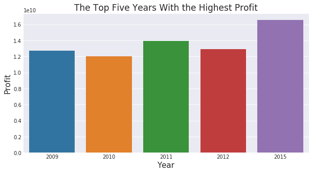

```python
#ploting our data for proper visualisation
plt.figure(figsize=(10,5))
sns.barplot(x='year', y='profit', data=year_p)#barchart
plt.title('The Top Five Years With the Highest Profit', fontsize=17)# the title of our diagram
plt.xlabel('Year',fontsize=15)
plt.ylabel('Profit',fontsize=15)
plt.show()
```

The barchart above shows that 2015 has the highest profit followed with 2011,2012,2009 and 2010

### Research Question 2: What are the top five movies when profit is expressed as a percentage of budget for each movie?

For us to answer this question, we need to create a ne column called profit_by_budget. This profit_of_budget will be created by dividing our profit column data with the budget column and multiply it by 100 to get the percentage value.

```python
#creating a new column called profit_of_budget
df['profit_by_budget'] = df['profit'] // df['budget'] * 100
```

```python
#lets view the first two rows of our data to confirm if our new column was created
df.head()
```

|  | id | popularity | budget | revenue | original_title | director | overview | runtime | genres | production_companies | release_date | vote_count | vote_average | release_year | profit | profit_by_budget |
| --- | --- | --- | --- | --- | --- | --- | --- | --- | --- | --- | --- | --- | --- | --- | --- | --- |
| 0 | 135397 | 32.985763 | 150000000 | 1513528810 | Jurassic World | Colin Trevorrow | Twenty-two years after the events of Jurassic ... | 124 | Action\|Adventure\|Science Fiction\|Thriller | Universal Studios\|Amblin Entertainment\|Legenda... | 2015-06-09 | 5562 | 6.5 | 2015 | 1363528810 | 900 |
| 1 | 76341 | 28.419936 | 150000000 | 378436354 | Mad Max: Fury Road | George Miller | An apocalyptic story set in the furthest reach... | 120 | Action\|Adventure\|Science Fiction\|Thriller | Village Roadshow Pictures\|Kennedy Miller Produ... | 2015-05-13 | 6185 | 7.1 | 2015 | 228436354 | 100 |
| 2 | 262500 | 13.112507 | 110000000 | 295238201 | Insurgent | Robert Schwentke | Beatrice Prior must confront her inner demons ... | 119 | Adventure\|Science Fiction\|Thriller | Summit Entertainment\|Mandeville Films\|Red Wago... | 2015-03-18 | 2480 | 6.3 | 2015 | 185238201 | 100 |
| 3 | 140607 | 11.173104 | 200000000 | 2068178225 | Star Wars: The Force Awakens | J.J. Abrams | Thirty years after defeating the Galactic Empi... | 136 | Action\|Adventure\|Science Fiction\|Fantasy | Lucasfilm\|Truenorth Productions\|Bad Robot | 2015-12-15 | 5292 | 7.5 | 2015 | 1868178225 | 900 |
| 4 | 168259 | 9.335014 | 190000000 | 1506249360 | Furious 7 | James Wan | Deckard Shaw seeks revenge against Dominic Tor... | 137 | Action\|Crime\|Thriller | Universal Pictures\|Original Film\|Media Rights ... | 2015-04-01 | 2947 | 7.3 | 2015 | 1316249360 | 600 |

```python
#lets see the data type of our new column
df.profit_by_budget.dtypes
```

```
dtype('int64')
```

```python
df.info()
```

```
<class 'pandas.core.frame.DataFrame'>
Int64Index: 1287 entries, 0 to 10760
Data columns (total 16 columns):
id                      1287 non-null int64
popularity              1287 non-null float64
budget                  1287 non-null int64
revenue                 1287 non-null int64
original_title          1287 non-null object
director                1287 non-null object
overview                1287 non-null object
runtime                 1287 non-null int64
genres                  1287 non-null object
production_companies    1287 non-null object
release_date            1287 non-null datetime64[ns]
vote_count              1287 non-null int64
vote_average            1287 non-null float64
release_year            1287 non-null int64
profit                  1287 non-null int64
profit_by_budget        1287 non-null int64
dtypes: datetime64[ns](1), float64(2), int64(8), object(5)
memory usage: 170.9+ KB
```

```python
# Convert the profit_of_budget to float
df.profit_by_budget = df.profit_by_budget.astype(float)
```

```python
#Let's confirm if it has been converted to float
df.info()
```

```
<class 'pandas.core.frame.DataFrame'>
Int64Index: 1287 entries, 0 to 10760
Data columns (total 16 columns):
id                      1287 non-null int64
popularity              1287 non-null float64
budget                  1287 non-null int64
revenue                 1287 non-null int64
original_title          1287 non-null object
director                1287 non-null object
overview                1287 non-null object
runtime                 1287 non-null int64
genres                  1287 non-null object
production_companies    1287 non-null object
release_date            1287 non-null datetime64[ns]
vote_count              1287 non-null int64
vote_average            1287 non-null float64
release_year            1287 non-null int64
profit                  1287 non-null int64
profit_by_budget        1287 non-null float64
dtypes: datetime64[ns](1), float64(3), int64(7), object(5)
memory usage: 170.9+ KB
```

We can see that our profit_by_budget column data has been converted to float

```python
#sorting our data to get the first five movie titles with the highest profit expressed as a percentage of there budget
movie_p = df[['original_title','profit_by_budget']].sort_values('profit_by_budget', ascending=False).head()
movie_p
```

|  | original_title | profit_by_budget |
| --- | --- | --- |
| 3608 | From Prada to Nada | 2688000.0 |
| 7447 | Paranormal Activity | 1288900.0 |
| 2449 | The Blair Witch Project | 991900.0 |
| 3581 | Love, Wedding, Marriage | 137700.0 |
| 242 | The Gallows | 42500.0 |

We can see that `From Prada to Nada` movie has the highest profit when expressed as a percentage of it's budget.

Let's plot our information on a chart for proper visualization.

```python
movie_p.set_index('original_title', inplace=True)
```

```python
movie_p
```

| original_title | profit_by_budget |
| --- | --- |
| From Prada to Nada | 2688000.0 |
| Paranormal Activity | 1288900.0 |
| The Blair Witch Project | 991900.0 |
| Love, Wedding, Marriage | 137700.0 |
| The Gallows | 42500.0 |

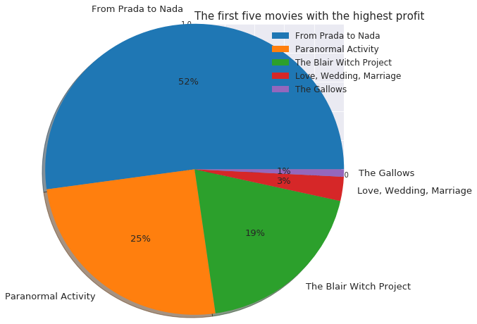

```python
#defining the size of our diagram
plt.figure(figsize=(3.8,3.8))

#size of our movie title text
textprops = {"fontsize":13}

#organizing our data in a piechart for proper visualisation
plt.pie(movie_p.profit_by_budget, labels=movie_p.index, textprops = textprops, autopct ='%.0f%%', shadow=True, frame=True)

#legend
plt.legend(labels=movie_p.index, loc='upper center', bbox_to_anchor=(0.95,1), ncol=1, fontsize=12)

#Title of our piechart
plt.title('The first five movies with the highest profit', loc='left', fontsize = 15)

#display
plt.show()
```